# International Cherry Blossom Prediction Competition

- Show All Code
- Hide All Code
- View Source

Supplementary data extraction

Author

Edimer David Jaramillo

Published

February 27, 2024

# Libraries and setup

```r
library(tidyverse)
library(geodata)
library(fs)
library(meteor)

source("../source/r/extractPhotoperiod.R")

path_export <- "../external-data/other/"
```

# Coordinates

```r
# Coordinates from csv
coord_japan <- read_csv("../data/japan.csv") |>
  distinct(lat, long)

coord_kyoto <- read_csv("../data/kyoto.csv") |>
  distinct(lat, long)

coord_liestal <- read_csv("../data/liestal.csv") |>
  distinct(lat, long)

coord_vancouver <- read_csv("../data/vancouver.csv") |>
  distinct(lat, long)

coord_washingtondc <- read_csv("../data/washingtondc.csv") |>
  distinct(lat, long)

coord_meteoswiss <- read_csv("../data/meteoswiss.csv") |>
  distinct(lat, long)

coord_southk <- read_csv("../data/south_korea.csv") |>
  distinct(lat, long)

# Coordinates New York ----
coord_newyork <-
  data.frame(long = -73.99809,
             lat = 40.73040)

# Coordinates USA National Phenology Network
coord_npn1 <- read_csv("../data/USA-NPN_individual_phenometrics_data.csv") |>
  select(lat = Latitude, long = Longitude) |>
  distinct_all()

coord_npn2 <- read_csv("../data/USA-NPN_status_intensity_observations_data.csv") |>
  select(lat = Latitude, long = Longitude) |>
  distinct_all()

coord_npn <- bind_rows(coord_npn1, coord_npn2) |>
  distinct_all()
```

# Other data

- Through the library [`geodata`](https://cran.r-project.org/web/packages/geodata/geodata.pdf#page=6&zoom=100,132,89) the following information is obtained:
  - **Cropland:** Cropland data (*cropland*). This data is derived from [ESA WorldCover.](https://esa-worldcover.org/en)
  - **Footprint:** “The ‘human footprint’ is an estimate of direct and indirect human pressures on the environment. Human pressure is measured using eight variables including urbanized environments, population density, electric power infrastructure, cropland, grasslands, roads, railways and waterways. It is expressed on a scale from 0 (low) to 50 (high footprint).” [`geodata` library.](https://cran.r-project.org/web/packages/geodata/geodata.pdf#page%20=%2011&zoom=100,132,89) - [Scientific article 2009](https://www.nature.com/articles/sdata201667)
  - **Land cover:** data was obtained for tree, grassland, shrub and water cover.
- All data were obtained for a spatial resolution of 0.5 minutes (~1km2).

## Cropland

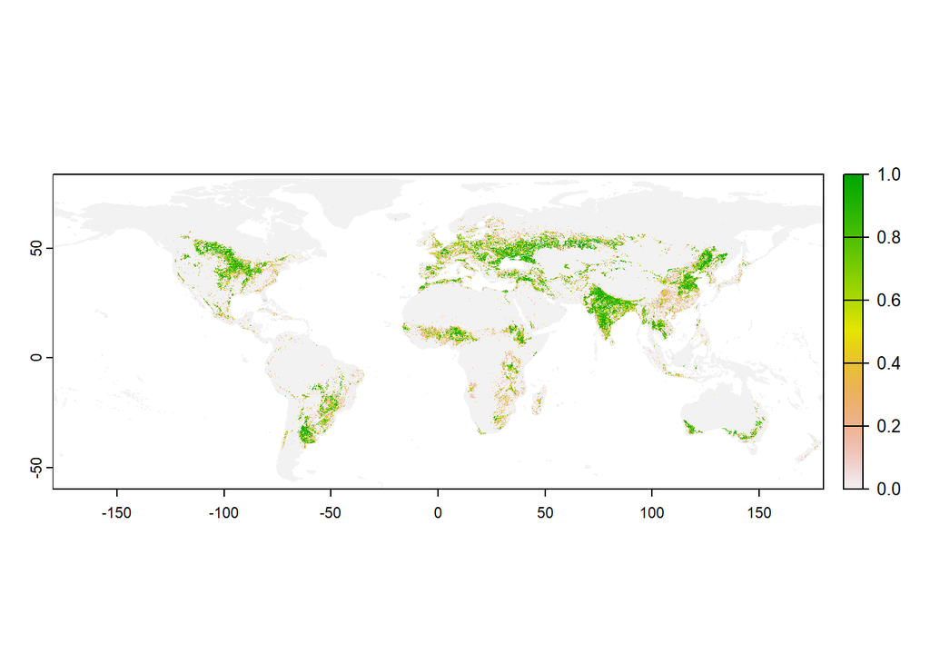

```r
data_cropland <-
  cropland(source = "WorldCover",
           path = path_export)

data_cropland |> plot()
```

**Japan**

```r
cropland_japan <-
  data_cropland |>
  extract(y = coord_japan |> relocate(long, lat),
          xy = FALSE) |>
  select(-ID)

df_cropland_japan <-
  coord_japan |>
  bind_cols(cropland_japan)
```

**Kyoto**

```r
cropland_kyoto <-
  data_cropland |>
  extract(y = coord_kyoto |> relocate(long, lat),
          xy = FALSE) |>
  select(-ID)

df_cropland_kyoto <-
  coord_kyoto |>
  bind_cols(cropland_kyoto)
```

**Switzerland**

```r
cropland_liestal <-
  data_cropland |>
  extract(y = coord_liestal |> relocate(long, lat),
          xy = FALSE) |>
  select(-ID)

cropland_meteoswiss <-
  data_cropland |>
  extract(y = coord_meteoswiss |> relocate(long, lat),
          xy = FALSE) |>
  select(-ID)

df_cropland_liestal <-
  coord_liestal |>
  bind_cols(cropland_liestal)

df_cropland_meteoswiss <-
  coord_meteoswiss |>
  bind_cols(cropland_meteoswiss)
```

**Canada**

```r
cropland_vancouver <-
  data_cropland |>
  extract(y = coord_vancouver |> relocate(long, lat),
          xy = FALSE) |>
  select(-ID)

df_cropland_vancouver <-
  coord_vancouver |>
  bind_cols(cropland_vancouver)
```

**USA**

```r
cropland_newyork <-
  data_cropland  |>
  extract(y = coord_newyork |> relocate(long, lat),
          xy = FALSE) |>
  select(-ID)

cropland_washingtondc <-
  data_cropland  |>
  extract(y = coord_washingtondc |> relocate(long, lat),
          xy = FALSE) |>
  select(-ID)

df_cropland_newyork <-
  coord_newyork |>
  bind_cols(cropland_newyork)

df_cropland_washingtondc <-
  coord_washingtondc |>
  bind_cols(cropland_washingtondc)

# NPN
cropland_npn <-
  data_cropland  |>
  extract(y = coord_npn |> relocate(long, lat),
          xy = FALSE) |>
  select(-ID)

df_cropland_npn <-
  coord_npn |>
  bind_cols(cropland_npn)
```

**South Korea**

```r
cropland_southk <-
  data_cropland |>
  extract(y = coord_southk |> relocate(long, lat),
          xy = FALSE) |>
  select(-ID)

df_cropland_southk <-
  coord_southk |>
  bind_cols(cropland_southk)
```

## Footprint

- Data is available for two years: 1993 and 2009

```r
footprint_93 <- footprint(year = 1993, path = path_export)
footprint_09 <- footprint(year = 2009, path = path_export)
footprint_full <- c(footprint_93, footprint_09)
```

**Japan**

```r
footprint_japan <-
  footprint_full |>
  extract(y = coord_japan |> relocate(long, lat),
          xy = FALSE) |>
  select(-ID)

df_footprint_japan <-
  coord_japan |>
  bind_cols(footprint_japan)
```

**Kyoto**

```r
footprint_kyoto <-
  footprint_full |>
  extract(y = coord_kyoto |> relocate(long, lat),
          xy = FALSE) |>
  select(-ID)

df_footprint_kyoto <-
  coord_kyoto |>
  bind_cols(footprint_kyoto)
```

**Switzerland**

```r
footprint_liestal <-
  footprint_full |>
  extract(y = coord_liestal |> relocate(long, lat),
          xy = FALSE) |>
  select(-ID)

footprint_meteoswiss <-
  footprint_full |>
  extract(y = coord_meteoswiss |> relocate(long, lat),
          xy = FALSE) |>
  select(-ID)

df_footprint_liestal <-
  coord_liestal |>
  bind_cols(footprint_liestal)

df_footprint_meteoswiss <-
  coord_meteoswiss |>
  bind_cols(footprint_meteoswiss)
```

**Canada**

```r
footprint_vancouver <-
  footprint_full |>
  extract(y = coord_vancouver |> relocate(long, lat),
          xy = FALSE) |>
  select(-ID)

df_footprint_vancouver <-
  coord_vancouver |>
  bind_cols(footprint_vancouver)
```

**USA**

```r
footprint_newyork <-
  footprint_full  |>
  extract(y = coord_newyork |> relocate(long, lat),
          xy = FALSE) |>
  select(-ID)

footprint_washingtondc <-
  footprint_full  |>
  extract(y = coord_washingtondc |> relocate(long, lat),
          xy = FALSE) |>
  select(-ID)

df_footprint_newyork <-
  coord_newyork |>
  bind_cols(footprint_newyork)

df_footprint_washingtondc <-
  coord_washingtondc |>
  bind_cols(footprint_washingtondc)

# NPN
footprint_npn <-
  footprint_full  |>
  extract(y = coord_npn |> relocate(long, lat),
          xy = FALSE) |>
  select(-ID)

df_footprint_npn <-
  coord_npn |>
  bind_cols(footprint_npn)
```

**South Korea**

```r
footprint_southk <-
  footprint_full |>
  extract(y = coord_southk |> relocate(long, lat),
          xy = FALSE) |>
  select(-ID)

df_footprint_southk <-
  coord_southk |>
  bind_cols(footprint_southk)
```

## Landcover

```r
var_landcover <- c("trees", "grassland", "shrubs",  "water")
list_landcover <- list()

for (i in 1:length(var_landcover)) {
  list_landcover[[i]] = landcover(var = var_landcover[i],
                                  path = path_export)
}

data_landcover <-
  c(list_landcover[[1]], list_landcover[[2]],
    list_landcover[[3]], list_landcover[[4]])
```

**Japan**

```r
landcover_japan <-
  data_landcover |>
  extract(y = coord_japan |> relocate(long, lat),
          xy = FALSE) |>
  select(-ID)

df_landcover_japan <-
  coord_japan |>
  bind_cols(landcover_japan)
```

**Kyoto**

```r
landcover_kyoto <-
  data_landcover |>
  extract(y = coord_kyoto |> relocate(long, lat),
          xy = FALSE) |>
  select(-ID)

df_landcover_kyoto <-
  coord_kyoto |>
  bind_cols(landcover_kyoto)
```

**Switzerland**

```r
landcover_liestal <-
  data_landcover |>
  extract(y = coord_liestal |> relocate(long, lat),
          xy = FALSE) |>
  select(-ID)

landcover_meteoswiss <-
  data_landcover |>
  extract(y = coord_meteoswiss |> relocate(long, lat),
          xy = FALSE) |>
  select(-ID)

df_landcover_liestal <-
  coord_liestal |>
  bind_cols(landcover_liestal)

df_landcover_meteoswiss <-
  coord_meteoswiss |>
  bind_cols(landcover_meteoswiss)
```

**Canada**

```r
landcover_vancouver <-
  data_landcover |>
  extract(y = coord_vancouver |> relocate(long, lat),
          xy = FALSE) |>
  select(-ID)

df_landcover_vancouver <-
  coord_vancouver |>
  bind_cols(landcover_vancouver)
```

**USA**

```r
landcover_newyork <-
  data_landcover  |>
  extract(y = coord_newyork |> relocate(long, lat),
          xy = FALSE) |>
  select(-ID)

landcover_washingtondc <-
  data_landcover  |>
  extract(y = coord_washingtondc |> relocate(long, lat),
          xy = FALSE) |>
  select(-ID)

df_landcover_newyork <-
  coord_newyork |>
  bind_cols(landcover_newyork)

df_landcover_washingtondc <-
  coord_washingtondc |>
  bind_cols(landcover_washingtondc)

# NPN
landcover_npn <-
  data_landcover  |>
  extract(y = coord_npn |> relocate(long, lat),
          xy = FALSE) |>
  select(-ID)

df_landcover_npn <-
  coord_npn |>
  bind_cols(landcover_npn)
```

**South Korea**

```r
landcover_southk <-
  data_landcover |>
  extract(y = coord_southk |> relocate(long, lat),
          xy = FALSE) |>
  select(-ID)

df_landcover_southk <-
  coord_southk |>
  bind_cols(landcover_southk)
```

## Complete data

**Japan**

```r
df_other_japan <-
  df_cropland_japan |>
  left_join(df_footprint_japan, by = c("long", "lat")) |>
  left_join(df_landcover_japan, by = c("long", "lat"))

write_csv(df_other_japan, "../external-data/other/other_japan.csv")
```

**Kyoto**

```r
df_other_kyoto <-
  df_cropland_kyoto |>
  left_join(df_footprint_kyoto, by = c("long", "lat")) |>
  left_join(df_landcover_kyoto, by = c("long", "lat"))

write_csv(df_other_kyoto, "../external-data/other/other_kyoto.csv")
```

**Switzerland**

```r
df_other_liestal <-
  df_cropland_liestal |>
  left_join(df_footprint_liestal, by = c("long", "lat")) |>
  left_join(df_landcover_liestal, by = c("long", "lat"))

df_other_meteoswiss <-
  df_cropland_meteoswiss |>
  left_join(df_footprint_meteoswiss, by = c("long", "lat")) |>
  left_join(df_landcover_meteoswiss, by = c("long", "lat"))

write_csv(df_other_liestal, "../external-data/other/other_liestal.csv")

write_csv(df_other_meteoswiss, "../external-data/other/other_meteoswiss.csv")
```

**Canada**

```r
df_other_vancouver <-
  df_cropland_vancouver |>
  left_join(df_footprint_vancouver, by = c("long", "lat")) |>
  left_join(df_landcover_vancouver, by = c("long", "lat"))

write_csv(df_other_vancouver, "../external-data/other/other_vancouver.csv")
```

**USA**

```r
df_other_newyork <-
  df_cropland_newyork |>
  left_join(df_footprint_newyork, by = c("long", "lat")) |>
  left_join(df_landcover_newyork, by = c("long", "lat"))

df_other_washingtondc <-
  df_cropland_washingtondc|>
  left_join(df_footprint_washingtondc, by = c("long", "lat")) |>
  left_join(df_landcover_washingtondc, by = c("long", "lat"))

df_other_npn <-
  df_cropland_npn |>
  left_join(df_footprint_npn, by = c("long", "lat")) |>
  left_join(df_landcover_npn, by = c("long", "lat"))

write_csv(df_other_newyork, "../external-data/other/other_newyork.csv")

write_csv(df_other_washingtondc, "../external-data/other/other_washingtondc.csv")

write_csv(df_other_npn, "../external-data/other/other_npn.csv")
```

**South Korea**

```r
df_other_southk <-
  df_cropland_southk |>
  left_join(df_footprint_southk, by = c("long", "lat")) |>
  left_join(df_landcover_southk, by = c("long", "lat"))

write_csv(df_other_southk, "../external-data/other/other_southk.csv")
```

# SoilGrids

```r
pattern_japan <- "japan"
pattern_switzerland <- "switzerland"
pattern_canada <- "canada"
pattern_usa <- "usa"
pattern_southk <- "southK"

path_sg <- "../external-data/soilgrids/"
files_sg <- path_sg |>
  dir_ls()
```

**Japan**

```r
list_sg <- list()
files_japan <-
  files_sg[str_detect(files_sg, pattern = pattern_japan)]

for (i in 1:length(files_japan)) {
  list_sg[[i]] = rast(x = files_japan[i])
}

tif_japan <-
  c(
    list_sg[[1]],
    list_sg[[2]],
    list_sg[[3]],
    list_sg[[4]],
    list_sg[[5]],
    list_sg[[6]],
    list_sg[[7]],
    list_sg[[8]],
    list_sg[[9]],
    list_sg[[10]],
    list_sg[[11]]
  )

sg_japan <-
  tif_japan |>
  extract(y = coord_japan |> relocate(long, lat),
          xy = FALSE) |>
  select(-ID)

df_sg_japan <-
  coord_japan |>
  bind_cols(sg_japan)

names(df_sg_japan) <-
  names(df_sg_japan) |>
  str_replace_all(glue::glue("_{pattern_japan}"), "")

write_csv(df_sg_japan, "../external-data/soilgrids/csv/sg_japan.csv")
```

**Kyoto**

```r
sg_kyoto <-
  tif_japan |>
  extract(y = coord_kyoto |> relocate(long, lat),
          xy = FALSE) |>
  select(-ID)

df_sg_kyoto <-
  coord_kyoto |>
  bind_cols(sg_kyoto)

names(df_sg_kyoto) <-
  names(df_sg_kyoto) |>
  str_replace_all(glue::glue("_{pattern_japan}"), "")

write_csv(df_sg_kyoto, "../external-data/soilgrids/csv/sg_kyoto.csv")
```

**Switzerland**

```r
list_sg <- list()
files_switzerland <-
  files_sg[str_detect(files_sg, pattern = pattern_switzerland)]

for (i in 1:length(files_switzerland)) {
  list_sg[[i]] = rast(x = files_switzerland[i])
}

tif_switzerland <-
  c(
    list_sg[[1]],
    list_sg[[2]],
    list_sg[[3]],
    list_sg[[4]],
    list_sg[[5]],
    list_sg[[6]],
    list_sg[[7]],
    list_sg[[8]],
    list_sg[[9]],
    list_sg[[10]],
    list_sg[[11]]
  )

# Liestal
sg_liestal <-
  tif_switzerland |>
  extract(y = coord_liestal |> relocate(long, lat),
          xy = FALSE) |>
  select(-ID)

df_sg_liestal <-
  coord_liestal |>
  bind_cols(sg_liestal)

names(df_sg_liestal) <-
  names(df_sg_liestal) |>
  str_replace_all(glue::glue("_{pattern_switzerland}"), "")

write_csv(df_sg_liestal, "../external-data/soilgrids/csv/sg_liestal.csv")

# Meteoswiss
sg_meteoswiss <-
  tif_switzerland |>
  extract(y = coord_meteoswiss |> relocate(long, lat),
          xy = FALSE) |>
  select(-ID)

df_sg_meteoswiss <-
  coord_meteoswiss |>
  bind_cols(sg_meteoswiss)

names(df_sg_meteoswiss) <-
  names(df_sg_meteoswiss) |>
  str_replace_all(glue::glue("_{pattern_switzerland}"), "")

write_csv(df_sg_meteoswiss, "../external-data/soilgrids/csv/sg_meteoswiss.csv")
```

**Canada**

```r
list_sg <- list()
files_canada <-
  files_sg[str_detect(files_sg, pattern = pattern_canada)]

for (i in 1:length(files_canada)) {
  list_sg[[i]] = rast(x = files_canada[i])
}

tif_canada <-
  c(
    list_sg[[1]],
    list_sg[[2]],
    list_sg[[3]],
    list_sg[[4]],
    list_sg[[5]],
    list_sg[[6]],
    list_sg[[7]],
    list_sg[[8]],
    list_sg[[9]],
    list_sg[[10]],
    list_sg[[11]]
  )

sg_vancouver <-
  tif_canada |>
  extract(y = coord_vancouver |> relocate(long, lat),
          xy = FALSE) |>
  select(-ID)

df_sg_vancouver <-
  coord_vancouver |>
  bind_cols(sg_vancouver)

names(df_sg_vancouver) <-
  names(df_sg_vancouver) |>
  str_replace_all(glue::glue("_{pattern_canada}"), "")

write_csv(df_sg_vancouver, "../external-data/soilgrids/csv/sg_vancouver.csv")
```

**USA**

```r
list_sg <- list()
files_usa <-
  files_sg[str_detect(files_sg, pattern = pattern_usa)]

for (i in 1:length(files_usa)) {
  list_sg[[i]] = rast(x = files_usa[i])
}

tif_usa <-
  c(
    list_sg[[1]],
    list_sg[[2]],
    list_sg[[3]],
    list_sg[[4]],
    list_sg[[5]],
    list_sg[[6]],
    list_sg[[7]],
    list_sg[[8]],
    list_sg[[9]],
    list_sg[[10]],
    list_sg[[11]]
  )

# New York
sg_newyork <-
  tif_usa |>
  extract(y = coord_newyork |> relocate(long, lat),
          xy = FALSE) |>
  select(-ID)

df_sg_newyork <-
  coord_newyork |>
  bind_cols(sg_newyork)

names(df_sg_newyork) <-
  names(df_sg_newyork) |>
  str_replace_all(glue::glue("_{pattern_usa}"), "")

write_csv(df_sg_newyork, "../external-data/soilgrids/csv/sg_newyork.csv")

# Washington DC
sg_washingtondc <-
  tif_usa |>
  extract(y = coord_washingtondc |> relocate(long, lat),
          xy = FALSE) |>
  select(-ID)

df_sg_washingtondc <-
  coord_washingtondc |>
  bind_cols(sg_washingtondc)

names(df_sg_washingtondc) <-
  names(df_sg_washingtondc) |>
  str_replace_all(glue::glue("_{pattern_usa}"), "")

write_csv(df_sg_washingtondc, "../external-data/soilgrids/csv/sg_washingtondc.csv")

# NPN
sg_npn <-
  tif_usa |>
  extract(y = coord_npn |> relocate(long, lat),
          xy = FALSE) |>
  select(-ID)

df_sg_npn <-
  coord_npn |>
  bind_cols(sg_npn)

names(df_sg_npn) <-
  names(df_sg_npn) |>
  str_replace_all(glue::glue("_{pattern_usa}"), "")

write_csv(df_sg_npn, "../external-data/soilgrids/csv/sg_npn.csv")
```

**South Korea**

```r
list_sg <- list()
files_southk <-
  files_sg[str_detect(files_sg, pattern = pattern_southk)]

for (i in 1:length(files_southk)) {
  list_sg[[i]] = rast(x = files_southk[i])
}

tif_southk <-
  c(
    list_sg[[1]],
    list_sg[[2]],
    list_sg[[3]],
    list_sg[[4]],
    list_sg[[5]],
    list_sg[[6]],
    list_sg[[7]],
    list_sg[[8]],
    list_sg[[9]],
    list_sg[[10]],
    list_sg[[11]]
  )

sg_southk <-
  tif_southk |>
  extract(y = coord_southk |> relocate(long, lat),
          xy = FALSE) |>
  select(-ID)

df_sg_southk <-
  coord_southk |>
  bind_cols(sg_southk)

names(df_sg_southk) <-
  names(df_sg_southk) |>
  str_replace_all(glue::glue("_{pattern_southk}"), "")

write_csv(df_sg_southk, "../external-data/soilgrids/csv/sg_southk.csv")
```

# Photoperiod

- The photoperiod is obtained with the library [`meteor`](https://cran.r-project.org/web/packages/meteor/meteor.pdf) using the `photoperiod()` function, which receives as parameters Enter the date and latitude. In this library the approach proposed by [Forsythe et al., 1995.](https://www.sciencedirect.com/science/article/abs/pii/030438009400034F) is used.
- To determine the photoperiod extraction ranges I use the minimum and maximum values of the flowering date. I have 1 year remaining from the minimum date to have information prior to flowering.

**Japan**

```r
photoperiod_japan <-
  extractPhotoperiod(data = read_csv("../data/japan.csv"))

arrow::write_parquet(photoperiod_japan,
                     "../external-data/other-photoperiod/photoperiod_japan.parquet")
```

**Kyoto**

```r
photoperiod_kyoto <-
  extractPhotoperiod(data = read_csv("../data/kyoto.csv"))

arrow::write_parquet(photoperiod_kyoto,
                     "../external-data/other-photoperiod/photoperiod_kyoto.parquet")
```

**Switzerland**

```r
photoperiod_liestal <-
  extractPhotoperiod(data = read_csv("../data/liestal.csv"))

arrow::write_parquet(photoperiod_liestal,
                     "../external-data/other-photoperiod/photoperiod_liestal.parquet")

photoperiod_meteoswiss <-
  extractPhotoperiod(data = read_csv("../data/meteoswiss.csv"))

arrow::write_parquet(photoperiod_meteoswiss,
                     "../external-data/other-photoperiod/photoperiod_meteoswiss.parquet")
```

**Canada**

```r
photoperiod_vancouver <-
  extractPhotoperiod(data = read_csv("../data/vancouver.csv"))

arrow::write_parquet(photoperiod_vancouver,
                     "../external-data/other-photoperiod/photoperiod_vancouver.parquet")
```

**USA**

```r
# Washington DC
photoperiod_washingtondc <-
  extractPhotoperiod(data = read_csv("../data/washingtondc.csv"))

arrow::write_parquet(photoperiod_washingtondc,
                     "../external-data/other-photoperiod/photoperiod_washingtondc.parquet")

# New York
range_newyork <-
  seq(from = ymd("2000-01-01"),
      to = ymd("2023-12-31"),
      by = 1)

photoperiod_newyork <-
  data.frame(
    photoperiod = photoperiod(x = range_newyork, latitude = coord_newyork$lat)
  )

arrow::write_parquet(photoperiod_newyork,
                     "../external-data/other-photoperiod/photoperiod_newyork.parquet")

# NPN
data_npn1 <- read_csv("../data/USA-NPN_individual_phenometrics_data.csv") |>
  mutate(Observation_Date = str_c(First_Yes_Month, "-", First_Yes_Day, "-", First_Yes_Year),
         Observation_Date = mdy(Observation_Date)) |>
  select(lat = Latitude,
         long = Longitude,
         bloom_date = Observation_Date) |>
  distinct_all()

data_npn2 <- read_csv("../data/USA-NPN_status_intensity_observations_data.csv") |>
  mutate(Observation_Date = mdy(Observation_Date)) |>
  select(lat = Latitude,
         long = Longitude,
         bloom_date = Observation_Date) |>
  distinct_all()

data_npn <- bind_rows(data_npn1, data_npn2) |>
  distinct_all()

photoperiod_npn <-
  extractPhotoperiod(data = data_npn)

arrow::write_parquet(photoperiod_npn,
                     "../external-data/other-photoperiod/photoperiod_npn.parquet")
```

**South Korea**

```r
photoperiod_southk <-
  extractPhotoperiod(data = read_csv("../data/south_korea.csv"))

arrow::write_parquet(photoperiod_southk,
                     "../external-data/other-photoperiod/photoperiod_southk.parquet")
```